# Difference-in-Differences in Stata — Day 1

From raw files to a credible 2×2

KDIS Summer Workshop 2026

Day 1 of 2

> **How to use this document.** This is a self-contained guide to Day 1: work through it on your own to review after class, or read ahead before it. Each step pairs the Stata command with the result it produces, so you can follow the reasoning on paper or open Stata and run along. To reproduce every figure and number here yourself, run `programs/day1.do` — it rebuilds the entire day from the raw data files.

# 1 The question

A national government has been expanding subsidized **public childcare**. Districts joined the program in different years. We want to know:

> **Did the program raise maternal employment?**

Today we answer that question for a *single* group of districts — the ones that joined in 2007 — compared against districts that never joined. That is the classic setting difference-in-differences was built for: **one treatment date, one control group.** On Wednesday we will use all the districts at once, and everything we learn today will break.

The same skeleton appears in every applied field: payments for forest conservation and forest cover, an anti-corruption reform and bribery rates, a minimum wage rise and employment (Card and Krueger’s 1994 classic). A program switches on — at a date, for some units and not others. Swap the nouns, and everything below applies unchanged.

Before asking whether a DiD design is *credible*, check whether it is even *possible*. DiD lives on **two dimensions of variation**, and you need both. The first is a contrast across units: the treatment must reach some and not others. If every unit is treated the same way, there is no comparison group. The second is a contrast over time: you must observe units both before and after treatment. With no pre-period, there is no baseline trend to difference out.

These two dimensions are *often* geography and calendar time — treated versus untreated regions, watched across years — but they need not be. Duflo’s (2001) study of school construction in Indonesia contrasted **regions** by how intensively they built schools against **birth cohorts** young enough to attend the new schools versus those already too old: region × cohort, not region × year. What matters is not that the axes are literally “space” and “time,” but that their interaction isolates the treatment. This is the first thing to check in any design of your own.

## 1.1 What you will be able to do by the end of today

1. Turn three messy raw files into an estimation panel.
2. Compute a difference-in-differences estimate from four sample means.
3. Get the *identical* number out of a regression, and know why they match.
4. Say precisely what the parallel trends assumption does and does not require.
5. Decide what to cluster your standard errors on.
6. Read an event-study plot.

# 2 The design, before any Stata

> **How to review this section.** In class we built this picture one figure at a time, with a question before each reveal. Reviewing on your own, play the same game against yourself: at each bold question, stop, commit to an answer, and only then read on. The wrong answers are part of the material — each stage exists to break the previous stage’s most tempting answer.

We want the causal effect of the program on the districts that adopted it. The obstacle is a missing observation, and it is always the same one: we observe the treated districts *with* the program, but we will never observe those same districts, over those same years, *without* it. Every causal design is a strategy for filling in that missing counterfactual. Difference-in-differences fills it in with the control group’s **change over time**.

## 2.1 The map, built one question at a time

The whole method fits in one picture, and the picture is easiest to understand when it is built in stages. The four figures below are generated by `programs/00_make_diagram.do` from invented round numbers; they are deliberately *not* drawn from today’s data, so every number is small enough to hold in your head.

### 2.1.1 Question 1: what is the effect?

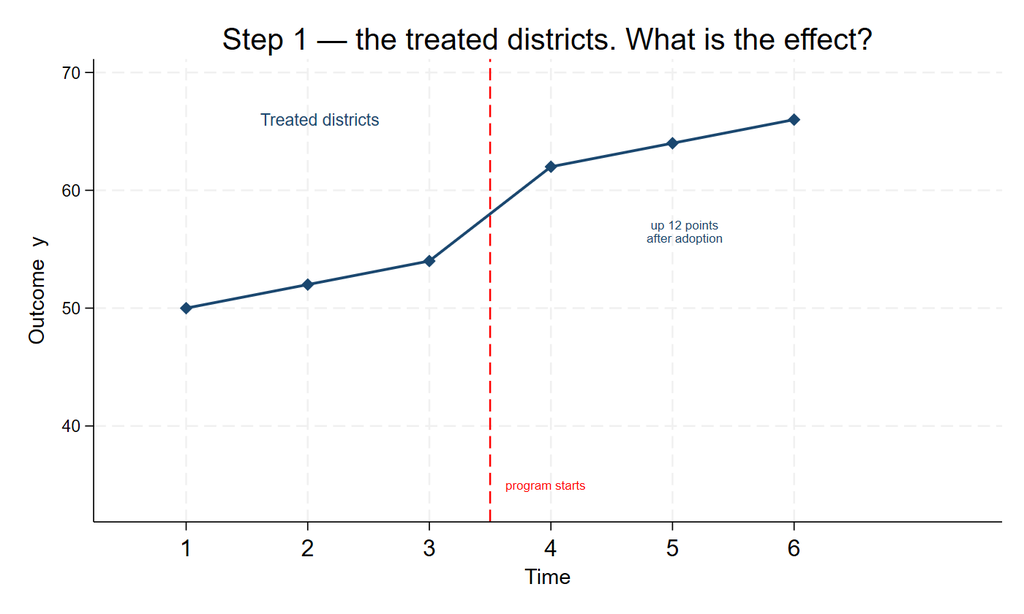

Step 1 — treated group only

The treated districts adopt the program and their outcome rises by 12 points over the following three years. **Stop here: what is the effect of the program?**

The tempting answer is 12 — or, if you are being careful, the jump between periods 3 and 4. Both answers make the same hidden assumption: that without the program, the outcome would have **stood still**. But look at the left half of the figure — the line was already rising before anyone was treated. A before–after comparison has no answer to “how much of the 12 would have happened anyway?” With only this figure, the honest answer is: *we cannot say.*

### 2.1.2 Question 2: what would let us say it?

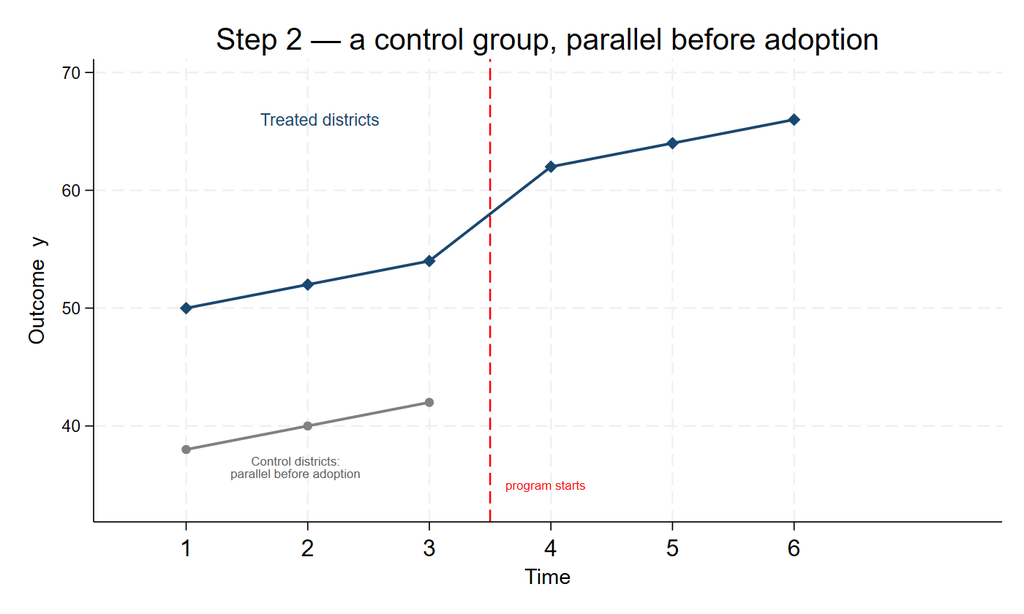

Step 2 — add a control group

We need an estimate of the missing quantity — the treated group’s path in the world without the program. **What information would let us construct it?**

The candidate: districts that never adopted. Before the program starts, they move **in parallel** with the treated districts — lower down, but gaining at the same rate per period. That parallel pre-period movement is what makes them a credible stand-in: it suggests both groups are being pushed along by the same common forces.

### 2.1.3 Question 3: now where is the effect?

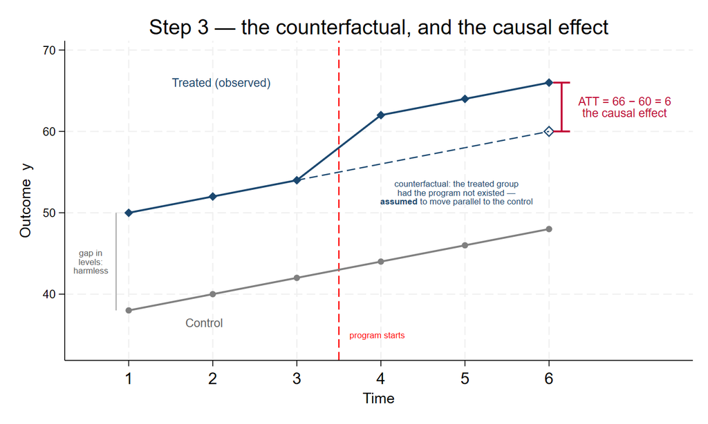

Step 3 — the completed map

The control group’s post-period completes the picture: it gains **6** over the same window in which the treated gained **12**. The arithmetic, in three steps:

1. Take the control group’s change — 6 points — as the estimate of what would have happened anyway.
2. Apply it to the treated group’s starting point: 54 + 6 = **60**. That is the dashed line: the counterfactual, the one object in the picture we never observe.
3. The effect is observed minus counterfactual: 66 − 60 = **6**. Identically: (66 − 54) − (48 − 42) = 12 − 6 = 6. The *difference* of two *differences*.

| Piece of the map | What it is | Observed? |
| --- | --- | --- |
| solid navy line | treated group’s outcome | yes |
| solid gray line | control group’s outcome | yes |
| 12-point gap in levels | permanent difference between groups | yes — and harmless |
| dashed line | treated group’s path *without* the program | **no — assumed** |
| red bracket | the causal effect (ATT) | only if the dashed line is right |

### 2.1.4 And the condition under which it breaks

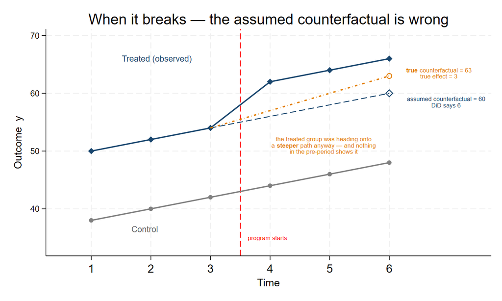

When it breaks

**One more question, before looking at the figure: what would have to be true for the 6 to be wrong?**

The orange line is a world in which the treated districts were heading onto a *steeper* path anyway — because of something that would have happened to them, and only them, with or without the program. In that world the true counterfactual is 63, the true effect is 3, and DiD still confidently reports 6.

Now the uncomfortable part: **compare the pre-periods of this figure and the previous one. They are identical.** Every observed point is the same in both worlds; the two figures differ only in the part we never see. No amount of data can tell you which world you are in. That is why what DiD rests on is called an *assumption* — and the next subsection states it precisely.

## 2.2 The assumption that makes it causal

Every element of the map is data except the dashed line. So the estimate is causal **if and only if the dashed line is drawn correctly** — and we drew it by assuming the treated group would have moved parallel to the control group. That is the entire content of the identifying assumption:

> **Parallel trends.** Had the program not existed, the treated group’s outcome would have changed by the same amount as the control group’s outcome actually changed.

In potential-outcomes notation, writing $y_{it}(0)$ for the outcome of district $i$ in year $t$ *in the world without the program*:

$$E\big[\,y_{i,\text{post}}(0) -
y_{i,\text{pre}}(0)\;\big|\;\text{Treated}\,\big]
\;=\;
E\big[\,y_{i,\text{post}}(0) -
y_{i,\text{pre}}(0)\;\big|\;\text{Control}\,\big]$$

For the control group, $y(0)$ is just the observed outcome. For the treated group in the post period, $y(0)$ is the dashed line — the quantity we cannot see and must assume.

## 2.3 Three things the assumption does *not* say

1. **It does not say the groups must be similar.** The 12-point level gap in the map is completely harmless — it is differenced out by construction. “These groups look nothing alike” is not an objection to a DiD design. “These groups were on different trajectories” is. The assumption is about **trends, not levels**.
2. **It is not testable.** It is a statement about the treated group’s counterfactual in the *post* period — a quantity that does not exist in any dataset. The break figure made this concrete: the good world and the broken world share every observed pre-period point. Watching the two groups move in parallel *before* treatment makes the assumption more plausible; it does not verify it. Hold on to that distinction between *supporting evidence* and *proof* — it does a lot of work on Wednesday.
3. **It does not say nothing else changed.** Recessions, national policies, demographic drift — all fine, *provided they hit both groups equally*, because the control group’s change absorbs them. What is fatal is anything that changes for **one group only, at the same time as treatment** — say, a second program targeted at the same districts in the same year. Then the control group’s change no longer measures “what would have happened anyway” for the treated.

## 2.4 What the number means when the assumption holds

The estimate is the **ATT** — the average effect of the treatment *on the treated*. It says what the program did in the districts that got it. It does not say what the program *would* do if extended to the control districts; those districts may be different in ways that also change the effect. Keeping “effect on the treated” and “effect for everyone” separate matters again on Wednesday, when different groups of districts turn out to experience genuinely different effects.

**The rest of today builds this map out of real files.** The raw trends plot is the map’s two solid lines drawn from data; the four-means table is its four observed points; the regression is the same arithmetic with a standard error attached; the event study checks how parallel the lines were before treatment. When in doubt at any point today, ask: *which piece of the map am I looking at?*

# 3 Getting the data in

Before any commands, the big picture. The map needs exactly one thing from the data: a **panel** — one row per district per year — holding the outcome (`emp_rate`), each district’s adoption year (`adopt_year`), and its population (`pop_thousands`). Every estimate produced today is computed from that one table: the outcome draws the map’s two solid lines, the adoption year says who is treated and when, the population comes in when we weight.

The agency, of course, does not send that table. It sends three files, and this whole section is the route from them to the panel — five steps, each ending with a check that tells you whether it is safe to keep going:

**import** (as text) → **destring** (fix the missings) → **reshape** (wide → long) → **merge** (three files → one) → **xtset** (declare the panel)

Here is what we receive, in the state a statistical agency actually sends it:

| File | Shape | What you must do |
| --- | --- | --- |
| `childcare_employment_wide.csv` | one row per district, one column per year | reshape and destring |
| `childcare_rollout.csv` | one row per district | merge `m:1` |
| `district_population.csv` | one row per district-year | merge `1:1` |

## 3.1 Import

We import **everything as text** first. That sounds perverse, but it means Stata cannot silently mangle a column, and we get to decide what is numeric.

```stata
import delimited "${raw}/childcare_employment_wide.csv", varnames(1) ///
    stringcols(_all) clear

list district_id yr2004 yr2005 yr2006 yr2007 in 1/5, noobs abbrev(12)
```

```
(encoding automatically selected: ISO-8859-1)
(18 vars, 180 obs)

  +-------------------------------------------------+
  | district_id   yr2004   yr2005   yr2006   yr2007 |
  |-------------------------------------------------|
  |       11001    42.54    46.08    45.22    43.93 |
  |       11002    50.99    52.26    52.33    51.97 |
  |       11003    53.66    50.49    53.15    55.48 |
  |       11004    48.99    47.30    50.01    50.01 |
  |       11005    53.33    52.71    53.02    53.41 |
  +-------------------------------------------------+
```

180 districts, 16 year-columns. The data is **wide**: one row per district.

## 3.2 Why `destring` fails the first time

Try to convert a year column to a number and Stata refuses:

```stata
destring yr2004, replace
```

```
yr2004: contains nonnumeric characters; no replace
```

This is the single most common frustration in applied work, and the fix is always the same: **look at the raw values.** The agency writes `..` for a missing observation. That is a character, so the whole column is text.

Blank it out first, *then* convert:

```stata
qui ds yr*
foreach v in `r(varlist)' {
    qui replace `v' = "" if `v' == ".."
}
destring yr*, replace
```

```
yr2004: all characters numeric; replaced as double
(5 missing values generated)
yr2005: all characters numeric; replaced as double
(2 missing values generated)
yr2006: all characters numeric; replaced as double
(8 missing values generated)
...
yr2019: all characters numeric; replaced as double
(3 missing values generated)
```

Those “missing values generated” messages are not errors — they are the `..` entries becoming proper Stata missings. **Read them.** They tell you how much data you actually have.

One more consequence of importing everything as text: the ID column is a string too, which will break the merge later if we don’t fix it now.

```stata
destring district_id, replace
describe district_id yr2004
```

```
district_id: all characters numeric; replaced as int

Variable      Storage   Display    Value
    name         type    format    label      Variable label
-------------------------------------------------------------------------------
district_id     int     %10.0g
yr2004          double  %10.0g
```

## 3.3 Reshape to long

Every panel command in Stata wants **one row per unit per period**.

```stata
reshape long yr, i(district_id) j(year)
rename yr emp_rate
label var emp_rate "Maternal employment rate (%)"

list district_id year emp_rate in 1/6, noobs abbrev(12)
```

```
Data                               Wide   ->   Long
-----------------------------------------------------------------------------
Number of observations              180   ->   2,880
Number of variables                  17   ->   3
j variable (16 values)                    ->   year
xij variables:
               yr2004 yr2005 ... yr2019   ->   yr
-----------------------------------------------------------------------------

  +-------------------------------+
  | district_id   year   emp_rate |
  |-------------------------------|
  |       11001   2004      42.54 |
  |       11001   2005      46.08 |
  |       11001   2006      45.22 |
  |       11001   2007      43.93 |
  |       11001   2008      46.17 |
  |       11001   2009      46.42 |
  +-------------------------------+
```

180 × 16 = 2,880 rows. The arithmetic should always check out; if it doesn’t, stop and find out why.

## 3.4 Merge in treatment status and population

```stata
merge m:1 district_id using `roll'     // adoption year: one row per district
merge 1:1 district_id year using `pop' // population: one row per district-year
```

```
    Result                      Number of obs
    -----------------------------------------
    Not matched                             0
    Matched                             2,880  (_merge==3)
    -----------------------------------------

    Result                      Number of obs
    -----------------------------------------
    Not matched                             0
    Matched                             2,880  (_merge==3)
    -----------------------------------------
```

The `m:1` versus `1:1` distinction is not decoration. `m:1` says “many district-years, one row per district” — if that claim is false, Stata stops. Let it check your beliefs for you.

**Never ignore `_merge`.** Zero unmatched here is the good case; if you see non-zero, find out which side and why before continuing.

# 4 What the panel looks like

```stata
xtset district_id year
tab adopt_year, missing
count if missing(emp_rate)
```

```
Panel variable: district_id (strongly balanced)
 Time variable: year, 2004 to 2019
         Delta: 1 unit

 adopt_year |      Freq.     Percent        Cum.
------------+-----------------------------------
       2007 |        720       25.00       25.00
       2010 |        720       25.00       50.00
       2013 |        720       25.00       75.00
       2016 |        480       16.67       91.67
          . |        240        8.33      100.00
------------+-----------------------------------
      Total |      2,880      100.00

  53
```

Four adoption cohorts and a group of districts that never joined (the `.` row — 15 districts × 16 years = 240). And 53 missing outcome values, so the panel is *strongly balanced in structure* but has holes in the data.

**Today we use only the 2007 cohort and the never-treated districts.** Everything else we set aside until Wednesday.

# 5 Look at the data before you estimate anything

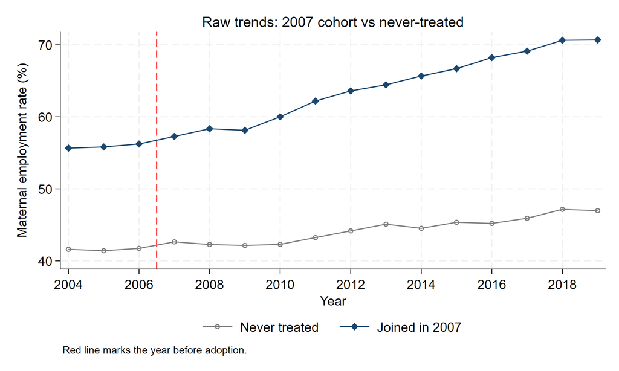

Raw trends

```stata
twoway (connected emp_rate year if grp==0, msymbol(Oh) lcolor(gs8) mcolor(gs8)) ///
       (connected emp_rate year if grp==1, msymbol(D)  lcolor(navy) mcolor(navy)), ///
    xline(2006.5, lpattern(dash) lcolor(red)) ///
    xlabel(2004(2)2019) ytitle("Maternal employment rate (%)") xtitle("Year") ///
    legend(position(6) row(1) order(1 "Never treated" 2 "Joined in 2007")) ///
    title("Raw trends: 2007 cohort vs never-treated")
```

## 5.1 Why the figure is built this way

`xline(2006.5)` sits at **2006.5, not 2007**. The program starts in 2007, so the last untreated year is 2006 and the first treated year is 2007. The line marks the *boundary between them*. Putting it at 2007 implies that year was still untreated, which is wrong. This is the single most common error in DiD figures.

`connected` rather than `scatter` or `line` shows both the markers (so readers can see which years you actually have data for) and the connecting line (so the trend is legible). With an unbalanced panel, markers are informative.

**Stop and look at this properly: it is the DiD map from the opening section, drawn by real data** — two solid lines, a level gap, and (so far) no dashed line, because we have not yet committed to a counterfactual.

The two groups are *miles apart in level*. Districts that joined in 2007 had maternal employment around 56%; districts that never joined were around 42%. A naive comparison of the two groups would attribute a 14-point gap to a program that had not started yet.

That gap is **not** what breaks difference-in-differences. Look instead at the **slopes before 2007**. They are close to parallel. That — and only that — is what the method needs.

> **The assumption is about trends, not levels.** “These groups look nothing alike” is not the same objection as “these groups were on different trajectories”. The two are easy to confuse — and only the second one is fatal.

# 6 The 2×2, computed by hand

Take two years: **2006** (before the program) and **2012** (five years in). Take two groups: districts that joined in 2007, and districts that never did. That gives four numbers.

```stata
table (treated) (post), stat(mean emp_rate) nformat(%7.3f)
```

```
-----------------------------------
        |            post
        |       0        1    Total
--------+--------------------------
treated |
  0     |  41.737   44.165   42.993
  1     |  56.224   63.590   59.950
  Total |  52.666   58.652   55.711
-----------------------------------
```

Now do the arithmetic that gives the method its name.

```stata
local d_treat = `t_post' - `t_pre'   // 63.590 - 56.224
local d_ctrl  = `c_post' - `c_pre'   // 44.165 - 41.737
local did     = `d_treat' - `d_ctrl'
```

```
  Change for treated districts   :   7.366
  Change for control districts   :   2.428
  ---------------------------------------
  Difference-in-differences      :   4.938
```

## 6.1 What that number means

Treated districts gained 7.37 points. But employment was rising everywhere — control districts gained 2.43 points over the same window with no program at all. So we credit the program with the **difference between the two changes**:

$$\widehat{\text{DiD}} \;=\; \underbrace{(\bar y_{T,\text{post}} - \bar
y_{T,\text{pre}})}_{7.366}
\;-\;\underbrace{(\bar y_{C,\text{post}} - \bar
y_{C,\text{pre}})}_{2.428}
\;=\; 4.938$$

The control group’s job is **not** to look like the treated group. Its job is to tell you what would have happened anyway.

# 7 The same number, from a regression

You will almost never compute four means by hand in real work. You will run a regression. Here is the model:

$$y_{it} \;=\; \beta_0 \;+\; \beta_1\,\text{Treated}_i \;+\;
\beta_2\,\text{Post}_t \;+\; \beta_3\,(\text{Treated}_i \times
\text{Post}_t) \;+\; \varepsilon_{it}$$

## 7.1 Equation → command

| Term in the equation | What it is | Stata |
| --- | --- | --- |
| $\beta_0$ | control group, pre-period mean | `_cons` |
| $\beta_1 \text{Treated}_i$ | permanent gap between groups | `i.treated` |
| $\beta_2 \text{Post}_t$ | common change over time | `i.post` |
| $\beta_3 (\text{Treated}_i \times \text{Post}_t)$ | **the DiD estimate** | `i.treated#i.post` |
| all three at once |  | `i.treated##i.post` |

The `##` operator expands to both main effects **and** their interaction. Writing `#` alone gives you only the interaction and silently omits the main effects, which is almost always a mistake.

```stata
reg emp_rate i.treated##i.post
```

```
------------------------------------------------------------------------------
    emp_rate | Coefficient  Std. err.      t    P>|t|     [95% conf. interval]
-------------+----------------------------------------------------------------
   1.treated |   14.48728   1.034789    14.00   0.000     12.43697    16.53758
      1.post |    2.42819   1.249689     1.94   0.055    -.0479071    4.904288
treated#post |
        1 1  |   4.937845   1.442825     3.42   0.001     2.079072    7.796619
       _cons |   41.73714   .8987697    46.44   0.000     39.95635    43.51794
------------------------------------------------------------------------------
```

**Read every coefficient against the table of four means above.**

- `_cons` = 41.737 — the control group’s pre-period mean, exactly.
- `1.treated` = 14.487 — the pre-period gap: 56.224 − 41.737.
- `1.post` = 2.428 — the control group’s change: 44.165 − 41.737.
- `treated#post` = **4.938** — the difference-in-differences, to three decimals the same number we computed by hand.

Nothing has been added by running a regression. It is the same arithmetic. What the regression *does* give us is a standard error — and covariates, if we want them.

# 8 Standard errors: what to cluster on

The same point estimate comes with three quite different standard errors:

```stata
reg emp_rate i.treated##i.post
reg emp_rate i.treated##i.post, robust
reg emp_rate i.treated##i.post, cluster(district_id)
```

```
  Default (homoskedastic) SE : 1.4428
  Robust SE                  : 1.2300
  Clustered by district SE   : 0.5959
```

Here clustering *shrinks* the standard error, which surprises people who have been told clustering always inflates it. It does not always. What clustering does is stop treating repeated observations on the same district as independent information.

**The rule to remember:** cluster at the level at which treatment is assigned. The program was assigned to *districts*, so districts are the clusters — not district-years, and not individuals.

With only two periods this matters less than it will on Wednesday. Once you have sixteen years of the same district, the outcome is strongly serially correlated and ignoring it produces standard errors that are far too small.

# 9 Using all sixteen years

Throwing away fourteen years of data to keep a tidy 2×2 is wasteful. The multi-period version replaces the two dummies with **fixed effects**:

$$y_{it} \;=\; \alpha_i \;+\; \lambda_t \;+\; \beta\,D_{it} \;+\;
\varepsilon_{it}$$

## 9.1 Equation → command

| Term | What it absorbs | Stata |
| --- | --- | --- |
| $\alpha_i$ | everything permanent about a district | `absorb(district_id)` |
| $\lambda_t$ | everything common to a year | `i.year` |
| $D_{it}$ | 1 once district $i$ has the program | `treat` |
| $\beta$ | **the effect we want** | coefficient on `treat` |
| clustering |  | `cluster(district_id)` |

```stata
gen byte treat = (adopt_year == 2007) & (year >= 2007)
areg emp_rate treat i.year, absorb(district_id) cluster(district_id)
```

```
Linear regression, absorbing indicators             Number of obs     =    939
Absorbed variable: district_id                      No. of categories =     60
                           (Std. err. adjusted for 60 clusters in district_id)
------------------------------------------------------------------------------
             |               Robust
    emp_rate | Coefficient  std. err.      t    P>|t|     [95% conf. interval]
-------------+----------------------------------------------------------------
       treat |   5.591371   .2313964    24.16   0.000     5.128347    6.054394
------------------------------------------------------------------------------
```

**5.59 percentage points**, averaged over all thirteen post-adoption years.

Why is this larger than the 4.94 we got from the 2×2? Because the 2×2 measured the effect in 2012 only — five years in. This averages over years one through thirteen, and as we are about to see, the effect keeps growing.

$\alpha_i$ absorbs *every* fixed district characteristic — geography, culture, the level differences that dominated the raw plot — without your having to measure any of them. That is what makes fixed effects powerful, and also what makes them easy to over-trust: they absorb nothing that *changes* over time.

# 10 The event study

A single number hides the shape of the effect. Replace the one `treat` dummy with **one dummy per year relative to adoption**:

$$y_{it} \;=\; \alpha_i \;+\; \lambda_t \;+\; \sum_{k \neq -1} \beta_k \,
\mathbf{1}\{t - g_i = k\} \;+\; \varepsilon_{it}$$

The year before adoption ($k = -1$) is left out; every $\beta_k$ is measured *relative to that year*. You must omit one, or the dummies are collinear with the fixed effects.

```stata
gen rel = year - 2007 if adopt_year == 2007
forvalues k = 3(-1)2 { qui gen byte lead_`k' = (rel == -`k') & !missing(rel) }
forvalues k = 0/12   { qui gen byte lag_`k'  = (rel ==  `k') & !missing(rel) }

areg emp_rate lead_3 lead_2 lag_* i.year, absorb(district_id) cluster(district_id)
```

```
------------------------------------------------------------------------------
             | Coefficient  Std. err.      t    P>|t|     [95% conf. interval]
-------------+----------------------------------------------------------------
      lead_3 |    .190979   .5274014     0.36   0.719    -.8643488    1.246307
      lead_2 |   .3015874   .4943579     0.61   0.544    -.6876205    1.290795
       lag_0 |   .5309113   .4602404     1.15   0.253    -.3900276     1.45185
       lag_1 |   2.045569   .4473525     4.57   0.000     1.150418    2.940719
       lag_2 |   1.856665   .5323762     3.49   0.001     .7913831    2.921948
       lag_3 |   3.510555   .4960255     7.08   0.000      2.51801      4.5031
       lag_4 |   4.830275   .4958856     9.74   0.000      3.83801     5.82254
       lag_5 |   5.288708   .5416055     9.76   0.000     4.204958    6.372458
       lag_6 |   5.311101    .522598    10.16   0.000     4.265384    6.356817
       lag_7 |   7.073429   .5856845    12.08   0.000     5.901477    8.245381
       lag_8 |   7.222699   .5826755    12.40   0.000     6.056768    8.388629
       lag_9 |   8.868716   .5393885    16.44   0.000     7.789402     9.94803
      lag_10 |   9.317721   .5302032    17.57   0.000     8.256787    10.37865
      lag_11 |   9.358921   .5251448    17.82   0.000     8.308108    10.40973
      lag_12 |   9.562436   .4359017    21.94   0.000     8.690198    10.43467
------------------------------------------------------------------------------
```

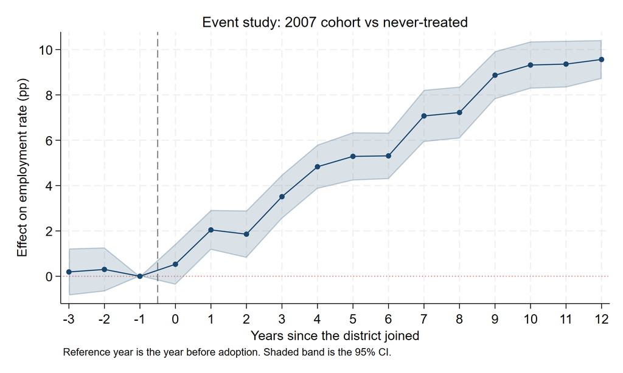

Event study

## 10.1 Why the event-study figure is built this way

An event-study plot has conventions, and readers of your paper will expect them.

**Plot the omitted period as an explicit zero.** In `day1.do`, the point $(-1, 0)$ is posted into the results before anything else is plotted. The coefficient at $k = -1$ is not estimated — it is the reference. Showing it as a point at exactly zero, with no confidence interval, tells the reader *which* period everything is measured against. Leaving it out makes readers guess, and they will guess wrong.

**The vertical line goes at $-0.5$**, between the last pre-period and the first post-period, for the same reason `xline(2006.5)` did above. Not at zero: period zero is already treated.

**Always draw the horizontal line at $y = 0$.** The entire question a reader brings to this figure is “are the pre-period estimates distinguishable from zero?” Make that comparison free.

**Confidence intervals are not optional.** A row of point estimates without them is uninterpretable — the reader cannot tell a precise zero from a noisy one. We use `rarea` for a shaded band here because the effect genuinely evolves smoothly. `rcap` (separate vertical bars) is the more conservative choice and arguably more honest for discrete event time, since a shaded band subtly implies you estimated something between the periods. Either is defensible; pick one and use it consistently.

**Do not put your finding in the title.** Title the figure with what it *shows* (“Event study: 2007 cohort vs never-treated”), not what you *concluded*. The figure should let the reader reach the conclusion. This matters more than it sounds — a title that announces the answer invites the suspicion that you went looking for it.

**Export properly.** `graph export "...png", replace width(2000)` gives you a slide-ready image. For journal submission use `.pdf` or `.eps` instead, which stay sharp at any size. Never screenshot a Stata graph window.

## 10.2 How to read this plot

**Left of the dashed line** is the evidence about your assumption. `lead_3` is 0.19 (p = 0.72) and `lead_2` is 0.30 (p = 0.54) — both indistinguishable from zero. The two groups were not drifting apart before the program started.

**Right of the dashed line** is the effect, and it is not a step. It starts near zero (`lag_0` = 0.53, not significant), reaches 5.3 points by year six, and levels off near 9.5 after a decade. That is exactly what you would expect from a program that has to build childcare centers before parents can use them.

This is why the single number 5.59 was a summary rather than an answer. The effect in year one and the effect in year eleven differ by a factor of five.

> **A warning to carry into Wednesday.** Flat pre-period coefficients are reassuring but they are *not proof* that parallel trends holds. They are a test with limited power, and on Wednesday we will see a case where the test is actively misleading.

# 11 Producing the table

Everything so far printed to your screen. **None of it is something you could put in a paper.** Stata’s console output is a diagnostic tool, not a result.

## 11.1 Why this matters more than it looks

The obvious thing to do is read the number off the screen and type it into Word. Do not do this, and the reason is not aesthetic.

Count the numbers in the table below: three coefficients, three standard errors, plus sample sizes and $R^2$ — around twenty cells. Now count how many times you will regenerate that table between today and publication. A referee asks you to add a control. You find a mistake in the cleaning code. Your co-author gets two more years of data. The journal wants the sample restricted. Ten rebuilds is a conservative estimate for a paper that actually gets published.

Ten rebuilds × twenty cells = **two hundred opportunities to mistype a number** — and, worse, a typo in a table is nearly impossible to catch, because nobody proofreads a table they have already proofread. The error survives to print.

There is a second cost that is less obvious and more dangerous. When updating a table is *tedious*, you avoid doing it. You tell yourself the change was small and the old numbers are close enough. That is how tables end up inconsistent with the text that describes them.

> **The rule: every number in your paper should be traceable to a line of code that produced it. If you typed it, you cannot trust it.**

## 11.2 Building it

We store each specification with `eststo` as we run it, then write them all out at once.

```stata
eststo clear

* (1) the 2x2
eststo c1: qui reg emp_rate i.treated##i.post, cluster(district_id)
estadd local yrs "2006, 2012"
estadd local dfe "No"

* (2) all sixteen years, two-way fixed effects
eststo c2: qui areg emp_rate tr i.year, absorb(district_id) cluster(district_id)
estadd local yrs "2004-2019"
estadd local dfe "Yes"

* (3) same, weighted by district population
eststo c3: qui areg emp_rate tr i.year [aw=pop_thousands], ///
    absorb(district_id) cluster(district_id)
```

`estadd local` is the feature that matters most for difference-in-differences specifically. A DiD table is judged on whether a reader can see **what each column actually did** — which fixed effects, which years, which sample. Those rows are not in the regression output; you add them yourself, and without them your table is unreadable.

```stata
local topts ///
    rename(1.treated#1.post DiD tr DiD) keep(DiD) ///
    b(%9.3f) se(%9.3f) star(* 0.10 ** 0.05 *** 0.01) ///
    coeflabels(DiD "Childcare program") varwidth(22) ///
    stats(yrs dfe yfe wgt N r2, fmt(%s %s %s %s %9.0g %9.3f) ///
      labels("Years used" "District FE" "Year FE" "Pop. weighted" ///
             "Observations" "R-squared"))

esttab c1 c2 c3, `topts' mtitles("2x2" "All years" "Weighted")
```

Storing the options in a local macro is not a stylistic flourish. It means the screen version, the Word version and the LaTeX version **cannot drift apart**, because they are literally the same options.

```
----------------------------------------------------------------------
                                (1)             (2)             (3)
                                2x2       All years        Weighted
----------------------------------------------------------------------
Childcare program             4.938***        5.591***        5.464***
                            (0.596)         (0.231)         (0.237)
----------------------------------------------------------------------
Years used               2006, 2012       2004-2019       2004-2019
District FE                      No             Yes             Yes
Year FE                          No             Yes             Yes
Pop. weighted                    No              No             Yes
Observations                    116             939             939
R-squared                     0.855           0.975           0.976
----------------------------------------------------------------------
Standard errors in parentheses
* p<0.10, ** p<0.05, *** p<0.01
```

## 11.3 Exporting

Two lines, same options, two formats:

```stata
* Word
esttab c1 c2 c3 using "${res}/table1_did.rtf", replace `topts' ///
    mtitles("2x2" "All years" "Weighted") ///
    title("Effect of the childcare program on maternal employment")

* LaTeX
esttab c1 c2 c3 using "${res}/table1_did.tex", replace booktabs `topts' ///
    mtitles("2x2" "All years" "Weighted") ///
    title("Effect of the childcare program...\label{tab:did}")
```

`.rtf` opens directly in Word with the formatting intact. `.tex` with `booktabs` produces a table you `\input{}` into your paper — so when you rebuild, the paper picks up the new numbers with no action from you at all.

You now have a genuine result: the program raised maternal employment by between 4.9 and 5.6 points depending on specification, and the estimate is stable across all three.

**On Wednesday you will watch every number in this table change.** Rebuilding the table will cost you one command, because the table is code; if it lived in Word, every cell would have to be found and retyped by hand. Today, never-type-a-number is advice you are taking on faith. On Wednesday it pays off in front of you.

# 12 Exercises

1. **Change the comparison window.** Redo the 2×2 with 2005 as the pre-year and 2019 as the post-year. Does the estimate go up or down? Explain why using the event-study plot.
2. **A placebo test.** Pretend the program started in 2005 instead of 2007, and drop all data from 2007 onward. Estimate the DiD. What should you find, and do you?
3. **Weighting.** Re-estimate the multi-period specification with `[aweight = pop_thousands]`. Does weighting by district size change the answer? Should it?
4. **Clustering, deliberately wrong.** Run the multi-period regression clustering on `year` instead of `district_id`. How many clusters do you have, and why is that a problem?
5. **Add a column** *(optional)*. Add a fourth column to Table 1 restricting the sample to 2004–2015, and give it its own `estadd local` specification rows. You should not have to touch columns 1–3 to do this, and the exported Word and LaTeX files should update on their own.

**Done in class, at the end of the day.** The final block of the day is for doing these exercises here, in groups, with help available. Each group finishes exercises 1, 2, 3, and 4 before leaving (exercise 5 is optional). Put everything in one do-file that runs top to bottom and writes a log: `log using "day1_hw_group3.log", replace text` at the top, a `display` line naming the group members, `log close` at the bottom, written answers in comments. Submit both the `.do` and the `.log` before leaving. Doing this on both days is what earns the workshop’s **Open Badge (Digital Badge)** — a verifiable, portable digital credential. (The workshop carries no academic credit.)

# 13 What to take away

1. Look at raw trends before you estimate anything.
2. DiD is four sample means; the regression is bookkeeping for that arithmetic.
3. Parallel trends is about **slopes**, not gaps.
4. Cluster where treatment was assigned.
5. Event studies show the shape of an effect, and let others check your assumption.

**Wednesday:** everything above was true because a single group of districts adopted on a single date. We will use all four cohorts at once — and the method you just learned will return an answer that is wrong by a factor of forty.